# presentation

## Vizualizace dat a deskriptivní statistika

Biostatistika - L-example

[👤](https://ondrejmottl.github.io/) Ondřej Mottl

[Moodle](https://dl2.cuni.cz/course/view.php?id=106)

## Výsledky učení

Po absolvování této přednášky budete schopni:

- Rozlišit typy proměnných
- Zvolit odpovídající popis dat (deskriptivní statistiky)
- Zvolit vhodnou vizualizaci dat (grafy)
- Popsat variabilitu dat (rozptyl, směrodatná odchylka)
- Rozlišit typy proměnných a vybrat odpovídající graf

## Naše biologická otázka

Chceme vědět: **Jak velké jsou kolonie tučňáků na různých ostrovech Antarktidy?**

Jsou kolonie přibližně stejně velké, nebo se výrazně liší?

# Naše data

## Tučňáci z Palmer Station

Artwork by [Allison Horst](https://allisonhorst.github.io/palmerpenguins/articles/art.html)

## Palmer Penguins

Vědci z projektu Palmer Penguins každoročně prováděli průzkumy tučňáků na třech ostrovech u Antarktidy.

U každého průzkumu si zapsali **počet tučňáků**.

## Palmer Penguins

Zapisujeme si počet tučňáků z průzkumu. Můžeme mít 10, 16, 18, 20, … tučňáků.

| Průzkum | Počet tučňáků |
| --- | --- |
| 1 | 10 |

## Palmer Penguins

Zapisujeme si počet tučňáků z průzkumu. Můžeme mít 10, 16, 18, 20, … tučňáků.

| Průzkum | Počet tučňáků |
| --- | --- |
| 1 | 10 |
| 2 | 18 |

## Palmer Penguins

Zapisujeme si počet tučňáků z průzkumu. Můžeme mít 10, 16, 18, 20, … tučňáků.

| Průzkum | Počet tučňáků |
| --- | --- |
| 1 | 10 |
| 2 | 18 |
| 3 | 16 |

## Palmer Penguins

Zapisujeme si počet tučňáků z průzkumu. Můžeme mít 10, 16, 18, 20, … tučňáků.

| Průzkum | Počet tučňáků |
| --- | --- |
| 1 | 10 |
| 2 | 18 |
| 3 | 16 |
| 4 | 20 |

## Palmer Penguins

Zapisujeme si počet tučňáků z průzkumu. Můžeme mít 10, 16, 18, 20, … tučňáků.

| Průzkum | Počet tučňáků |
| --- | --- |
| 1 | 10 |
| 2 | 18 |
| 3 | 16 |
| 4 | 20 |
| … | … |

## Otázka k zamyšlení

Víme, že máme 15 průzkumů s různými počty tučňáků. Jak bychom tato data uložili v R?

- 1. 15 samostatných proměnných (`pruzkum_1 <- 10`, `pruzkum_2 <- 18`, …)
- 2. Jeden vektor: `c(10, 18, 16, …)`
- 3. Tabulku se dvěma sloupci

## Palmer Penguins

```r
pocet_tucnaku <-
  c(
    10L # průzkum 1
  )
```

| Průzkum | Počet tučňáků |
| --- | --- |
| 1 | 10 |

## Palmer Penguins

```r
pocet_tucnaku <-
  c(
    10L, # průzkum 1
    18L  # průzkum 2
  )
```

| Průzkum | Počet tučňáků |
| --- | --- |
| 1 | 10 |
| 2 | 18 |

## Palmer Penguins

```r
pocet_tucnaku <-
  c(
    10L, # průzkum 1
    18L, # průzkum 2
    16L, # průzkum 3
    20L, # průzkum 4
    ... # další průzkumy
  )
```

| Průzkum | Počet tučňáků |
| --- | --- |
| 1 | 10 |
| 2 | 18 |
| 3 | 16 |
| 4 | 20 |
| … | … |

## Naše data

Získali jsme 15 průzkumových záznamů a zapsali počet tučňáků u každého z nich.

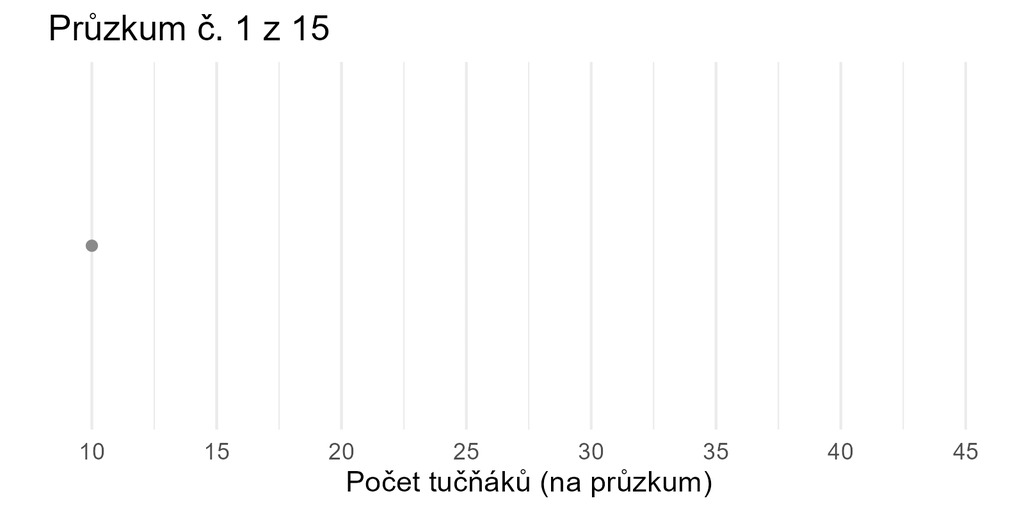

## Naše data

## Co vidíme v datech?

*Než pokračujeme — zapište si jednu věc, co z grafu vidíte.*

- Kde jsou průzkumy nejkoncentrovanější?
- Jsou v datech nějaké neobvyklé hodnoty?
- Jsou všechny průzkumy podobně velké, nebo jsou velké rozdíly?

## Naše data

Nyní máme data. Jak je **vizualizovat**?

# Vizualizace dat

## Proč nejdřív vizualizovat?

Dva vědci zkoumají kolonie tučňáků na dvou různých ostrovech. **Oba naměřili průměrný počet 7 tučňáků na průzkum. Jsou ostrovy biologicky stejné?**

```r
# Průměr – ostrov A
mean(c(5, 6, 6, 7, 7, 7, 8, 8, 9))
```

```
[1] 7
```

```r
# Průměr – ostrov B
mean(c(4, 4, 5, 5, 7, 9, 9, 10, 10))
```

```
[1] 7
```

## Proč nejdřív vizualizovat?

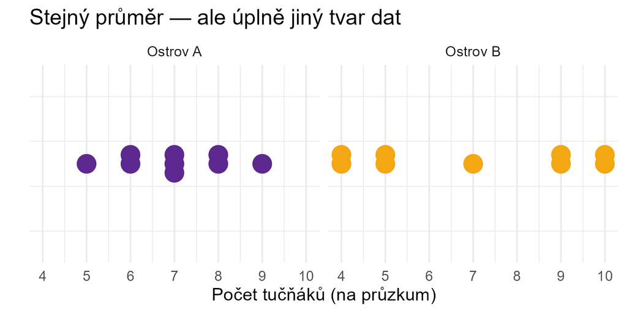

Ostrov A má průzkumy soustředěné kolem 7 – symetrická, stabilní kolonie. Ostrov B má průzkumy buď velmi malé, nebo velmi velké – to může signalizovat sezónní rozdíly nebo nestabilitu kolonie. **Stejné číslo, zásadně odlišná biologie.**

## Proč nejdřív vizualizovat?

Vždy nejdřív vizualizujte.

## Bodový graf (beeswarm)

Každý bod = jeden průzkum. Vidíme **všechna data** najednou.

- vidíme **každou hodnotu** zvlášť
- odhaluje **tvar distribuce** (kde jsou hodnoty nahloučené)
- snadno odhalí **odlehlé hodnoty**

## Otázka k zamyšlení

Bodový graf ukazuje každý průzkum zvlášť. Kdybychom průzkumy seskupili do „košů” po 5 tučňácích, co by znázorňovala výška sloupce?

- 1. Průměrný počet tučňáků v daném koši
- 2. Počet průzkumů, které spadají do daného koše
- 3. Celkový počet tučňáků v daném koši

## Histogram

Skupinujeme průzkumy do „košů“ podle počtu tučňáků. Výška sloupce = počet průzkumů v daném koši.

- ukazuje, kde jsou hodnoty **nahloučené**
- odhaluje **symetrii** nebo asymetrii distribuce
- závisí na šířce koše (`binwidth`) – vyzkoušejte různé hodnoty

## Graf hustoty

Graf hustoty (density plot) je „vyhlazený“ histogram – neukazuje počty, ale **relativní četnost** hodnot.

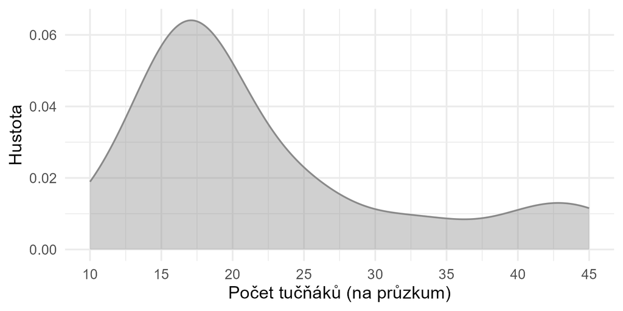

- „vyhlazená” verze histogramu – nezávisí na šířce koše
- ukazuje **relativní četnost**: kde jsou hodnoty pravděpodobnější
- vhodný pro porovnání **více skupin** najednou

## Jak interpretujeme tento graf?

- Kde jsou průzkumy nejčastější?
- Je distribuce symetrická nebo asymetrická?
- Který graf (bodový / histogram / hustota) byl pro vás nejinformativnější?

# Deskriptivní statistiky

## Čísla místo obrázků

Grafy jsou skvělé — ale v publikaci nebo při srovnání desítek skupin potřebujeme data popsat **jedním číslem**. Jaké číslo zvolit?

## Deskriptivní statistiky

### Minimum

Minimum nám říká, kolik tučňáků měl průzkum s nejnižším počtem tučňáků.

```r
min(pocet_tucnaku)
```

```
[1] 10
```

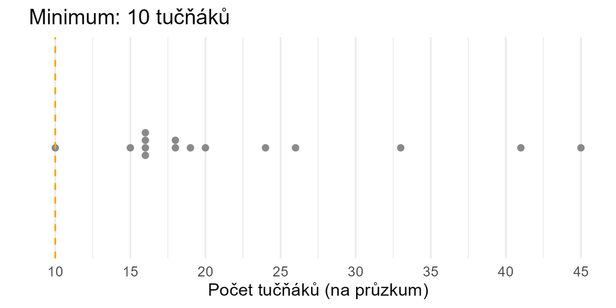

## Deskriptivní statistiky

### Maximum

Maximum nám říká, kolik tučňáků měl průzkum s nejvyšším počtem tučňáků.

```r
max(pocet_tucnaku)
```

```
[1] 45
```

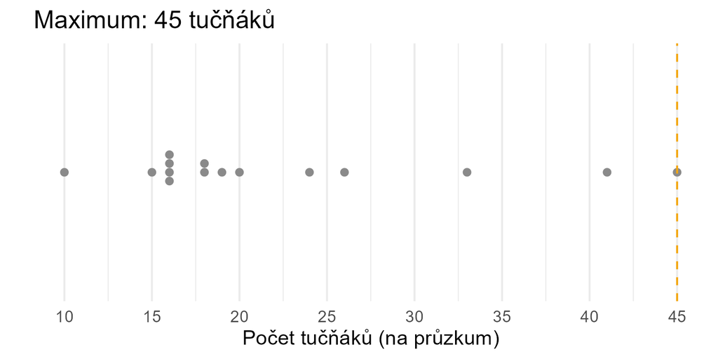

## Percentily

Percentil říká, jakou hodnotu nepřesahuje dané procento dat.

- **0. percentil** = minimum
- **50. percentil** = polovina průzkumů má méně, polovina více
- **100. percentil** = maximum

```r
quantile(pocet_tucnaku, probs = c(0, 0.25, 0.50, 0.75, 1))
```

```
  0%  25%  50%  75% 100%
  10   16   18   25   45
```

Percentily rozdělují data na části – 25. a 75. percentil jsou zvláště důležité.

## Deskriptivní statistiky

### Medián

Medián je **50. percentil** – polovina průzkumů má méně tučňáků, polovina více.

```r
median(pocet_tucnaku)
```

```
[1] 18
```

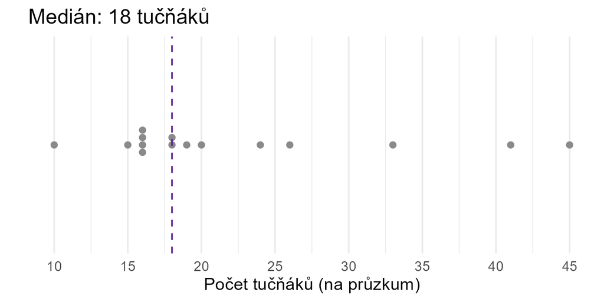

## Mezikvartilové rozpětí (IQR)

**Q1** = 25. percentil, **Q3** = 75. percentil.

IQR = Q3 - Q1 – rozpětí prostřední poloviny dat.

```r
quantile(pocet_tucnaku, 0.25) # Q1
```

```
25%
 16
```

```r
quantile(pocet_tucnaku, 0.75) # Q3
```

```
75%
 25
```

```r
IQR(pocet_tucnaku) # Q3 - Q1
```

```
[1] 9
```

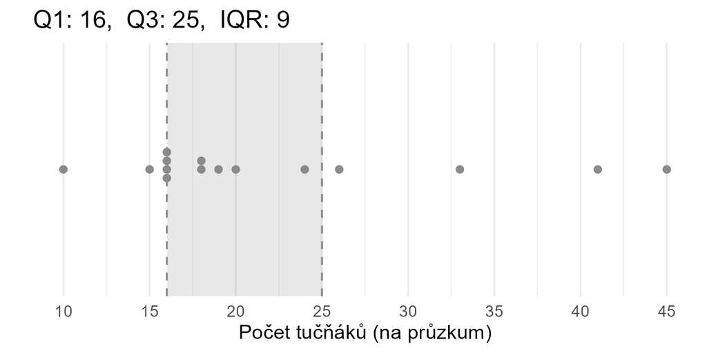

IQR je odolný vůči odlehlým hodnotám – popisuje **prostřední 50 %** dat.

## Deskriptivní statistiky

### Průměr

Průměr (mean) nám říká, jaký je typický počet tučňáků přes všechny průzkumy.

```r
mean(pocet_tucnaku)
```

```
[1] 22.2
```

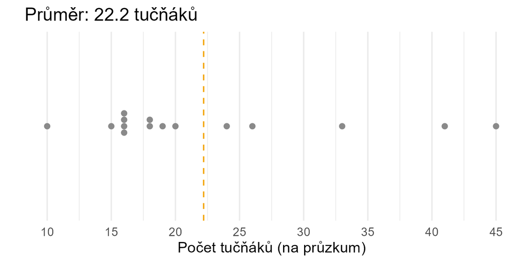

## Otázka k zamyšlení

Přidáme do dat jeden průzkum s **90 tučňáky**. Jak se změní průměr a medián?

- 1. Oba se zvýší přibližně stejně
- 2. Průměr se zvýší výrazně, medián jen mírně
- 3. Medián se zvýší výrazně, průměr jen mírně

## Průměr vs. Medián

Průměr a medián mohou být velmi odlišné, pokud jsou v datech **odlehlé hodnoty** (outliers).

Co kdybychom přidali neobyčlý průzkum s 90 tučňáky?

```r
mean(pocet_tucnaku)
```

```
[1] 22.2
```

```r
median(pocet_tucnaku)
```

```
[1] 18
```

**Bez odlehlé hodnoty**

```r
mean(pocet_tucnaku_outlier)
```

```
[1] 26.4375
```

```r
median(pocet_tucnaku_outlier)
```

```
[1] 18.5
```

**S odlehlou hodnotou**

Průměr je citlivý na odlehlé hodnoty. Medián je odolnejší – popisuje „typický“ případ lépe, pokud data nejsou symetrická.

## Rozptyl a směrodatná odchylka

Min, max, průměr a medián nám říkají, kde jsou data. Ale jak moc jsou data **rozptýlena**?

Směrodatná odchylka (standard deviation) nám říká, jak daleko jsou typicky hodnoty od průměru.

```r
sd(pocet_tucnaku)
```

```
[1] 10.04419
```

```r
var(pocet_tucnaku)
```

```
[1] 100.8857
```

Rozptyl (variance) = SD². V praxi se většinou používá SD – je ve stejných jednotkách jako data.

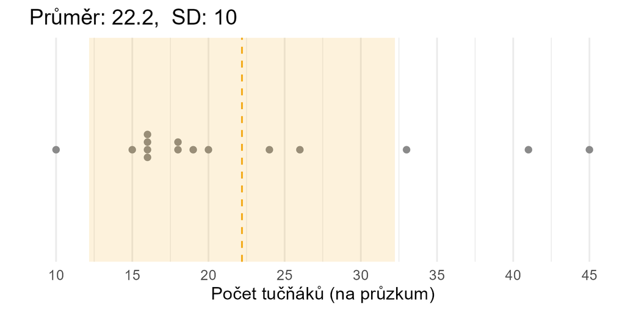

## Proč je SD důležité?

Dvě skupiny průzkumů mohou mít **stejný průměr**, ale velmi **různě rozptýlená** data.

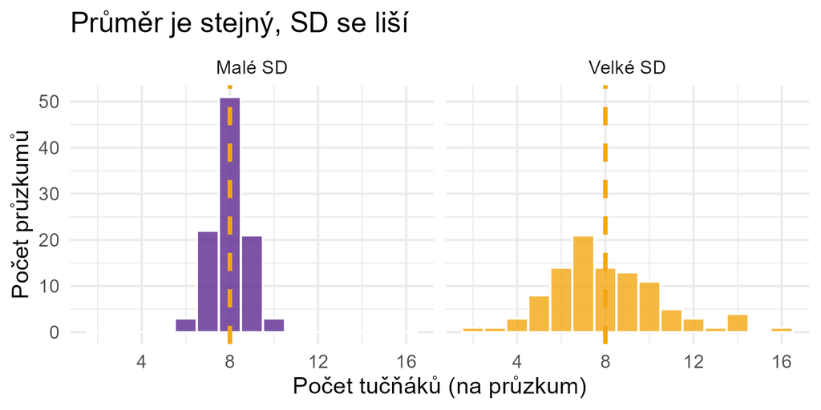

Stejný průměr ≠ stejná data. Směrodatná odchylka nám říká, jak moc jsou data „roztažená“.

# Statistiky jako vizualizace

## Od statistik ke grafu

Průměr – SD jsme viděli jako čísla a jako pásmo na grafu.

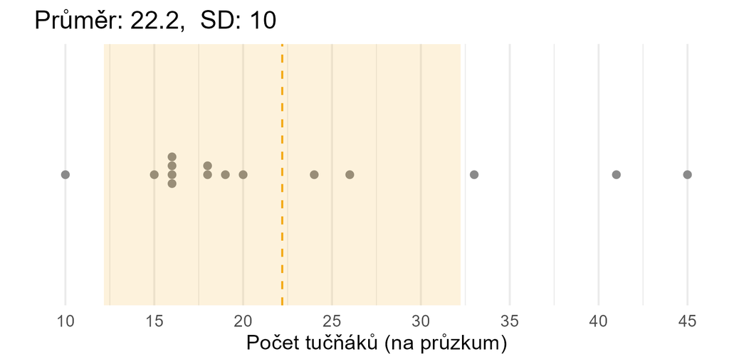

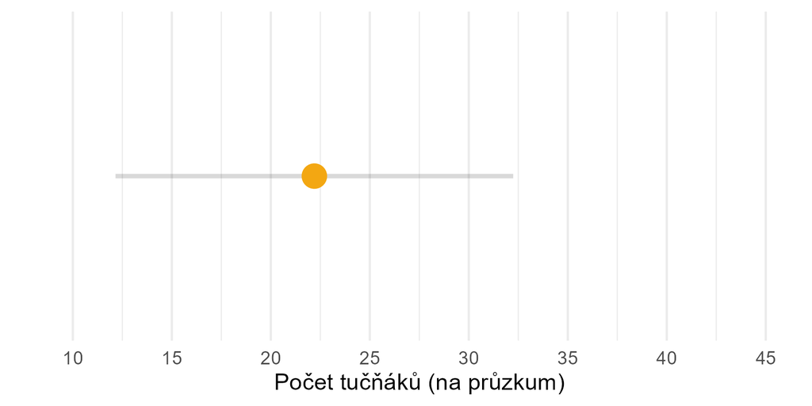

## Od statistik ke grafu

Co kdybychom statistiky **nakreslili jako tvar**?

## Krabicový graf (boxplot) – krok 1

Začneme s tím, co už známe: **medián**.

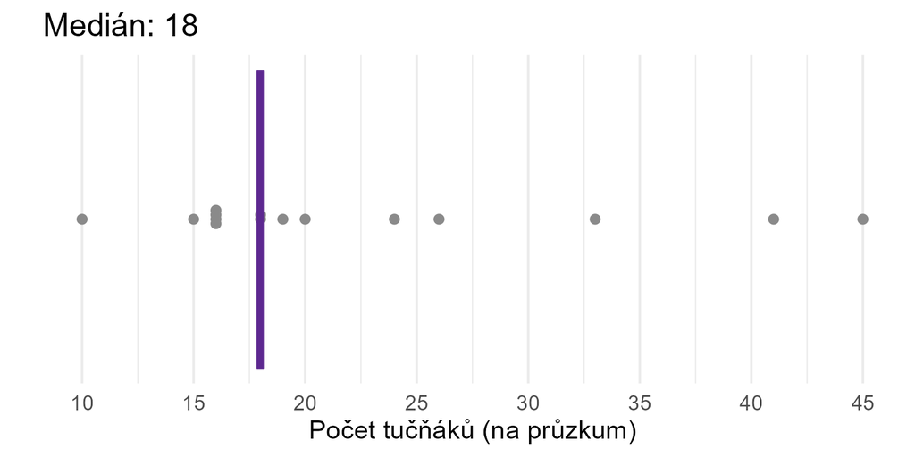

## Krabicový graf (boxplot) – krok 2

Přidáme **mezikvartilové rozpětí** (IQR): od 25. do 75. percentilu.

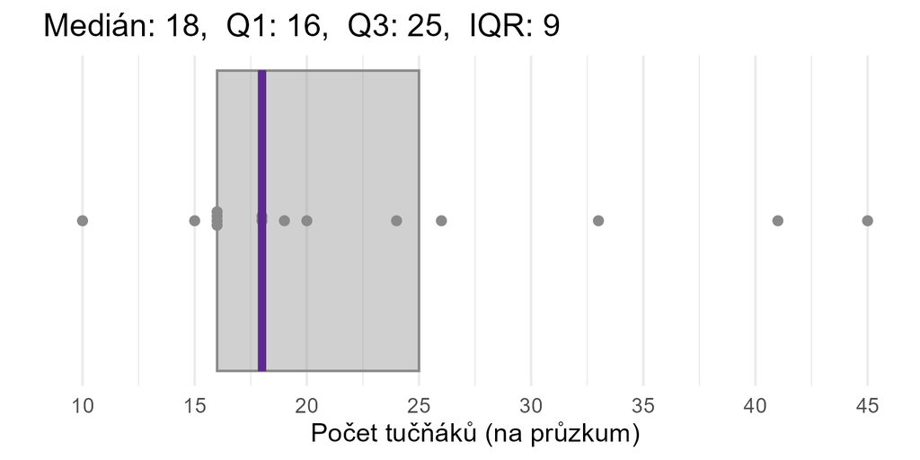

## Krabicový graf (boxplot) – krok 3

Přidáme **vousy** (1,5× IQR od krabice) a **odlehlé hodnoty** (body mimo vousy).

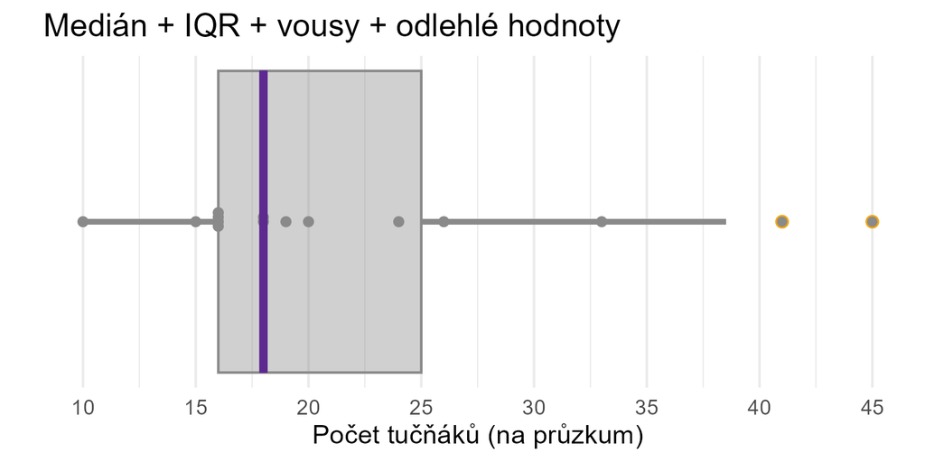

- Tlustá čára = **medián**
- Krabice = **IQR** (Q1–Q3)
- Vousy = 1,5× IQR od krabice
- Body = **odlehlé hodnoty**

*Toto je standardní ggplot2 boxplot – totéž, akorát nakreslený automaticky.*

## Krabicový graf

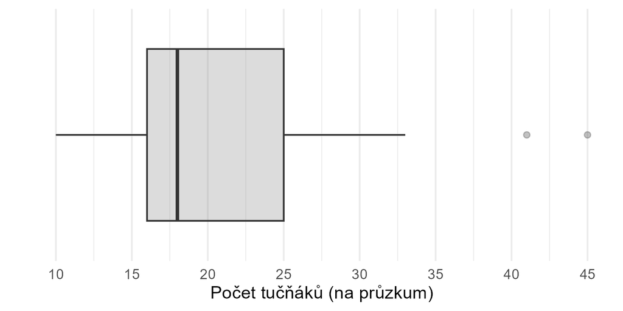

Boxplot není nový koncept – je to jen statistiky, které znáte, nakreslený jako tvar.

## Diskuze se sousedem (2 min)

Kamarád říká: „Přece víme průměr a SD — proč bychom kreslili boxplot?”

*Diskutujte se sousedem. Co byste mu odpověděli?*

# Typy proměnných

## Proč rozlišujeme typy proměnných?

Typ proměnné určuje:

- jaké **statistiky** dávají smysl (průměr počtu tučňáků ano; průměr druhu tučňáka ne)
- jakou **vizualizaci** zvolíme (beeswarm pro čísla, sloupcový graf pro kategorie)
- jak data správně **interpretujeme**

## Kvantitativní – diskrétní

- počet tučňáků na průzkum
- počet stromů v lese
- počet druhů ptáků na lokalitě
- počet planet ve Sluneční soustavě

Proměnná nabývající pouze **celočíselných** hodnot – nelze mít 7,3 stromu.

## Kvantitativní – diskrétní

```r
pocet_tucnaku <-
  c(10L, 18L, 16L, 20L) # celá čísla
```

Vizualizace: beeswarm nebo histogram.

## Kvantitativní – spojitá

- délka zobáku tučňáka v mm
- teplota vzduchu
- množství srážek
- hmotnost zvířete

Proměnná nabývající **jakékoli hodnoty** v intervalu – délka může být 39,1 mm nebo 40,34 mm.

Artwork by [Allison Horst](https://allisonhorst.github.io/palmerpenguins/articles/art.html)

## Kvantitativní – spojitá

```r
delka_zobaku <-
  c(39.1, 40.3, 36.7, 42.9) # desetinná čísla
```

Různé vizualizace odhalují různé vlastnosti dat.

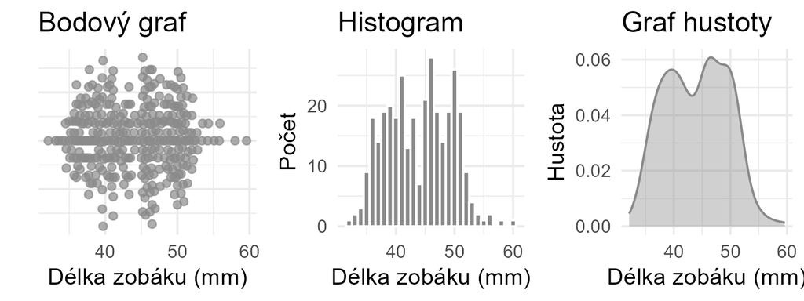

## Otázka k zamyšlení

Vědci zapsali **druh tučňáka** u každého jedince: *Adelie*, *Chinstrap*, *Gentoo*. Má smysl spočítat **průměrný druh tučňáka**?

- 1. Ano — průměr funguje pro jakákoliv data
- 2. Ne — druh tučňáka je kategorie, průměr nedává smysl
- 3. Záleží na tom, kolik druhů máme

Průměr lze spočítat jen pro **kvantitativní** proměnné. Pro kategorické proměnné používáme četnosti, podíly nebo modus.

## Kategorická – nominální

- druh tučňáka (Adelie, Chinstrap, Gentoo)
- druh hmyzu (včela, čmelák, motýl)
- typ stanoviště (les, louka, mokřad)
- krevní skupina (A, B, AB, 0)

Proměnná, jejíž hodnoty **nelze seřadit** – „Adelie“ není více ani méně než „Chinstrap“.

## Kategorická – nominální

```r
druh_tucnaku <-
  c("Adelie", "Chinstrap", "Adelie", "Gentoo")
```

Každá kategorie dostane vlastní barvu – vizuální kód odpovídá realitě.

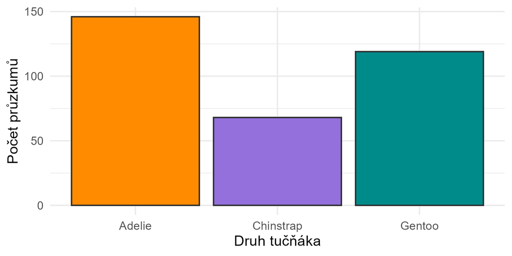

## Kategorická – nominální

Chceme ukázat **proporce** (ne počty)? Použijeme složený sloupcový graf nebo waffle.

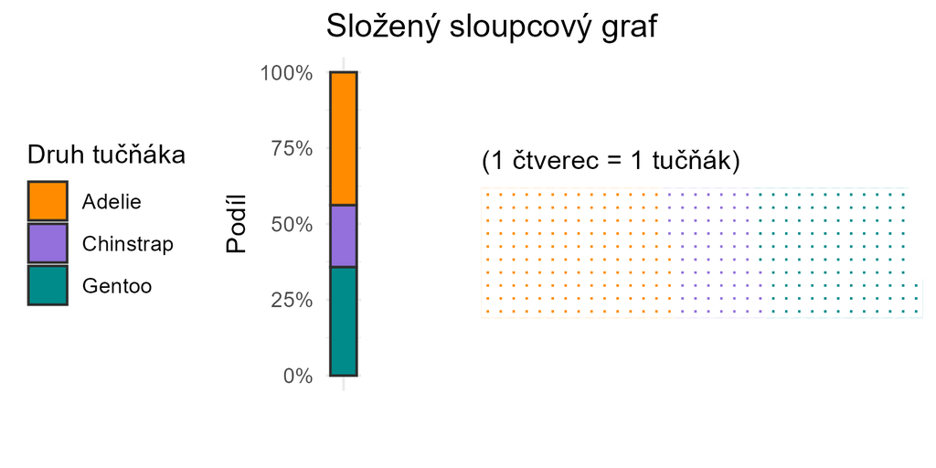

## Kategorická – ordinální

- hmotnostní kategorie tučňáka (malý, střední, velký)
- školní klasifikace (1, 2, 3, 4, 5)
- souhlas s výrokem (zcela souhlasím – zcela nesouhlasím)
- fáze měsíce (nový – úplněk)

Proměnná s **pořadím**, ale vzdálenost mezi stupni **není nutně stejná** – „velký“ není přesně dvakrát víc než „malý“.

## Kategorická – ordinální

```r
kategorie_hmotnosti <-
  factor(
    c("střední", "velký", "malý", "velký"),
    levels = c("malý", "střední", "velký"),
    ordered = TRUE
  )
```

Vizualizace: sloupcový graf s **seřazenou** osou.

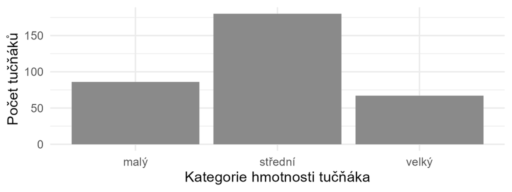

# Závěr

## Shrnutí

- **Na tučňácích jsme viděli**: stejný průměr může skrývat zásadně odlišnou biologii — proto vždy nejdřív vizualizujeme
- **Vždy nejdřív vizualizujte** — grafy odhalují, co čísla skrývají
- **Průměr je citlivý na odlehlé hodnoty** — medián je odolnější
- **Boxplot** shrnuje medián, IQR, vousy a odlehlé hodnoty najednou
- **Typ proměnné** určuje správnou statistiku i vizualizaci
- **Střed ≠ popis variability** — potřebujeme obojí

## Závěrečná otázka

Kdy byste **nepoužili průměr**?

- Kdy data obsahují odlehlé hodnoty
- Kdy je distribuce silně asymetrická
- Kdy chcete popsat „typický” případ ve zkosených datech